# Kids Feet Length t-Test

## Background

These [data](https://webmailbyui-my.sharepoint.com/:x:/g/personal/harmkenn_byui_edu/Ee2RRg5H3RZIl1tfeK9QUh8BgbujF0r_jXZipv8JfO6OKA?e=5I4L5K) were collected by a statistician, Mary C. Meyer, in a fourth grade classroom in Ann Arbor, MI, in October 1997. They are a convenience sample — the kids who were in the fourth grade.

**Question:** Is the average foot length of fourth graders born in 1987 larger than the average foot length of the younger fourth graders born in 1988?

**Hypotheses**
$${ H }_{ 0 }:{ \mu }_{87Length}={ \mu }_{88Length}\\ { H }_{ a }:{ \mu }_{87Length}>{ \mu }_{88Length}$$

## Analysis

### Compare the Lengths of Feet for 4th Graders born in ’87 and ’88

```r
KidsFeet$birthyear<-as.factor(KidsFeet$birthyear)
pander::pander(favstats(length~birthyear, data = KidsFeet))
```

| birthyear | min | Q1 | median | Q3 | max | mean | sd | n | missing |
| --- | --- | --- | --- | --- | --- | --- | --- | --- | --- |
| 87 | 24 | 24.95 | 25.5 | 26.05 | 27.5 | 25.57 | 1.143 | 7 | 0 |
| 88 | 21.6 | 23.85 | 24.45 | 25.27 | 27.1 | 24.54 | 1.295 | 32 | 0 |

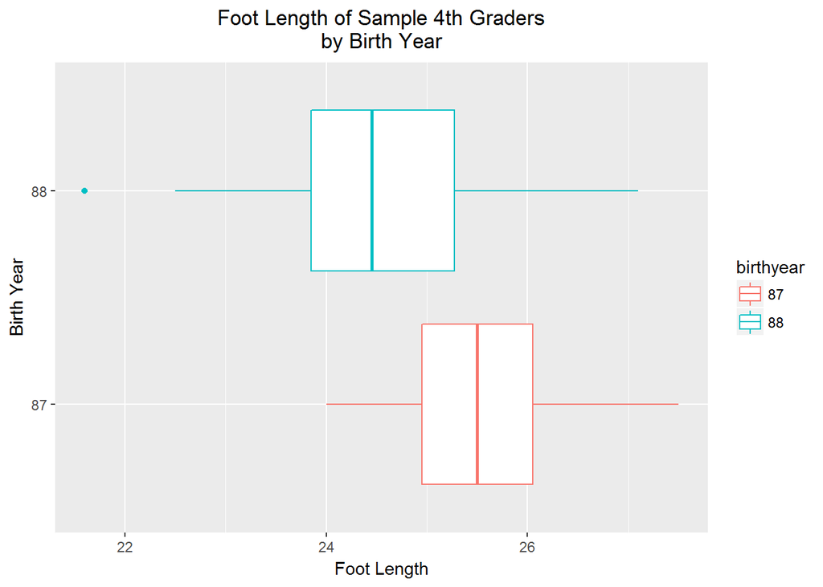

```r
ggplot(data = KidsFeet, aes(x = birthyear, y = length)) + geom_boxplot()  + aes(colour = birthyear) + labs(title = "Foot Length of Sample 4th Graders\nby Birth Year") + coord_flip() +labs(y="Foot Length",x="Birth Year")+ theme(plot.title = element_text(hjust = 0.5))
```

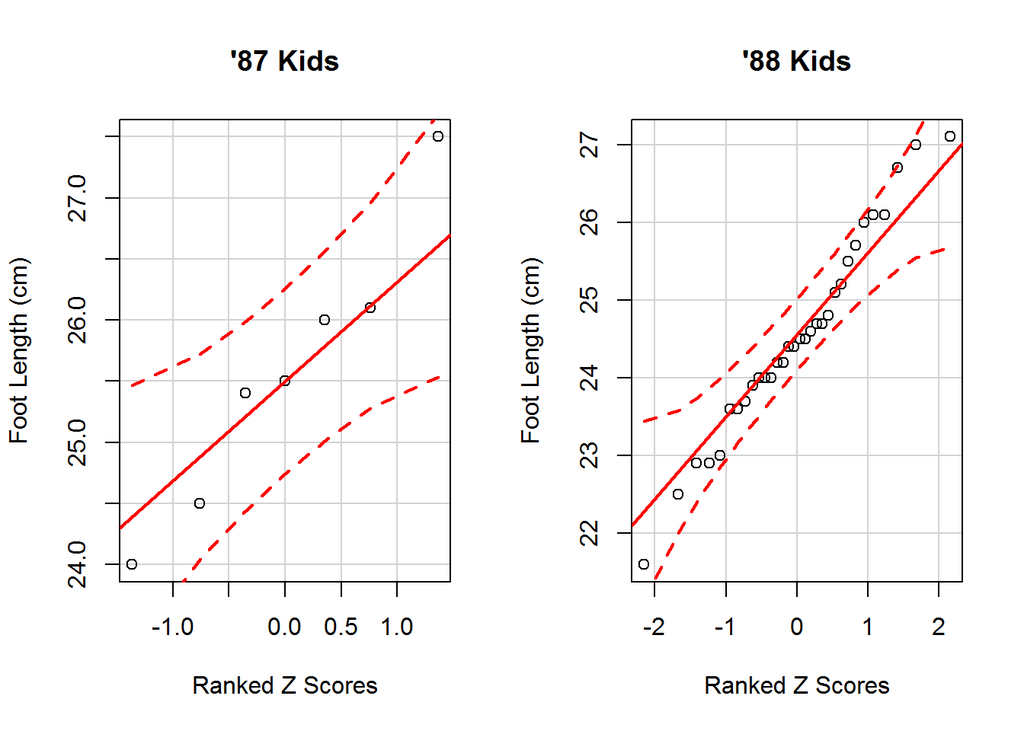

```r
Y87<-subset(KidsFeet, birthyear %in% 87)
par(mfrow=c(1,2))
qqPlot(Y87$length, xlab = "Ranked Z Scores", ylab = "Foot Length (cm)", main = "'87 Kids")


Y88<-subset(KidsFeet, birthyear %in% 88)
qqPlot(Y88$length, xlab = "Ranked Z Scores", ylab = "Foot Length (cm)", main = "'88 Kids")
```

### Assumptions

1. These samples **cannot** be assumed to be representative an any significant population because it is a convenience sample.
2. According to the QQ-Plots these samples appear to be normal enough.

### Independent 2 sample t-Test

Using a **level of significance:** $\alpha = .05$

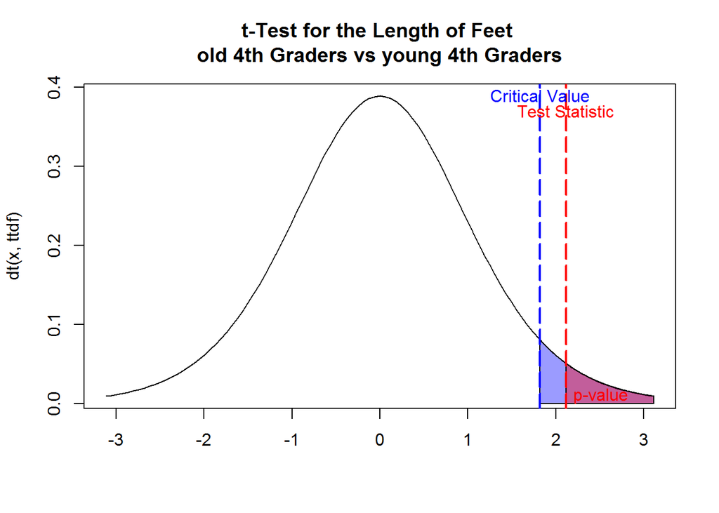

```r
ttp<-t.test(Y87$length,Y88$length, mu = 0, alternative = "greater", conf.level = 0.90)$p.value
tts<-t.test(Y87$length,Y88$length, mu = 0, alternative = "greater", conf.level = 0.90)$statistic
ttdf<-t.test(Y87$length,Y88$length, mu = 0, alternative = "greater", conf.level = 0.90)$parameter

U<-abs(tts)+1
L<-U*(-1)

tcv<-qt(.95, ttdf)

# Create data for the area to shade
TX<-seq(tts,U,.01)
cord.x <- c(tts,TX,U)
cord.y <- c(0,dt(TX,ttdf),0)

TCX<-seq(tcv,U,.01)
cord.x1 <- c(tcv,TCX,U)
cord.y1 <- c(0,dt(TCX,ttdf),0)

# Make a curve
curve(dt(x,ttdf), xlim=c(L,U), main="t-Test for the Length of Feet \nold 4th Graders vs young 4th Graders", xlab = "")

# Add the shaded area.

polygon(cord.x1,cord.y1,col='#0000FF64')
#transred<-rgb(255,0,0,max=255,alpha=100,names="transred")
polygon(cord.x,cord.y,col='#FF000064')
abline(v=tts, lty=5, col="red", lwd=2)
abline(v=tcv, lty=5, col="blue", lwd=2)
text(tcv,.39,"Critical Value", col="blue")

text(tts,.37,"Test Statistic", col="red")
text(tts+.4,.01,"p-value", col="red")
```

```r
pander(t.test(Y87$length,Y88$length, mu = 0, alternative = "greater", conf.level = 0.95))
```

Welch Two Sample t-test: `Y87$length` and `Y88$length` (continued below)

| Test statistic | df | P value | Alternative hypothesis | mean of x |
| --- | --- | --- | --- | --- |
| 2.115 | 9.698 | 0.03068 * | greater | 25.57 |

| mean of y |
| --- |
| 24.54 |

## Interpretation

- The Test Statistic **(2.1151522)** is greater than the Critical Value **(1.8182151)**
- The p-value **(0.0306809)** is smaller than the Level of Significance **$\alpha = .05$**

Therefore, there is **sufficient evidence** to conclude that 4th Graders born in ’87 have a larger mean foot size than 4th Graders born in ’88.